# Risk Factor Analysis

## Outcome Variable

**Outcome Variable:** y_rate_wtkg

## Predictor Variables

**Intervention Variable:** fhtcm

**Adjustment Set:**

unadjusted

## Stratifying Variables

The analysis was stratified on these variable(s):

- agecat
- studyid
- country

## Data Summary

| agecat | studyid | country | fhtcm | n_cell | n |
| --- | --- | --- | --- | --- | --- |
| 0-3 months | ki1000304b-SAS-CompFeed | INDIA | >=167 cm | 94 | 212 |
| 0-3 months | ki1000304b-SAS-CompFeed | INDIA | <162 cm | 53 | 212 |
| 0-3 months | ki1000304b-SAS-CompFeed | INDIA | [162-167) cm | 65 | 212 |
| 0-3 months | ki1101329-Keneba | GAMBIA | >=167 cm | 768 | 1181 |
| 0-3 months | ki1101329-Keneba | GAMBIA | <162 cm | 82 | 1181 |
| 0-3 months | ki1101329-Keneba | GAMBIA | [162-167) cm | 331 | 1181 |
| 0-3 months | ki1119695-PROBIT | BELARUS | >=167 cm | 5497 | 5884 |
| 0-3 months | ki1119695-PROBIT | BELARUS | <162 cm | 76 | 5884 |
| 0-3 months | ki1119695-PROBIT | BELARUS | [162-167) cm | 311 | 5884 |
| 0-3 months | ki1135781-COHORTS | GUATEMALA | >=167 cm | 18 | 110 |
| 0-3 months | ki1135781-COHORTS | GUATEMALA | <162 cm | 58 | 110 |
| 0-3 months | ki1135781-COHORTS | GUATEMALA | [162-167) cm | 34 | 110 |
| 3-6 months | ki1000304b-SAS-CompFeed | INDIA | >=167 cm | 83 | 186 |
| 3-6 months | ki1000304b-SAS-CompFeed | INDIA | <162 cm | 47 | 186 |
| 3-6 months | ki1000304b-SAS-CompFeed | INDIA | [162-167) cm | 56 | 186 |
| 3-6 months | ki1101329-Keneba | GAMBIA | >=167 cm | 673 | 1039 |
| 3-6 months | ki1101329-Keneba | GAMBIA | <162 cm | 75 | 1039 |
| 3-6 months | ki1101329-Keneba | GAMBIA | [162-167) cm | 291 | 1039 |
| 3-6 months | ki1119695-PROBIT | BELARUS | >=167 cm | 4950 | 5297 |
| 3-6 months | ki1119695-PROBIT | BELARUS | <162 cm | 69 | 5297 |
| 3-6 months | ki1119695-PROBIT | BELARUS | [162-167) cm | 278 | 5297 |
| 3-6 months | ki1135781-COHORTS | GUATEMALA | >=167 cm | 17 | 116 |
| 3-6 months | ki1135781-COHORTS | GUATEMALA | <162 cm | 61 | 116 |
| 3-6 months | ki1135781-COHORTS | GUATEMALA | [162-167) cm | 38 | 116 |
| 6-9 months | ki1000304b-SAS-CompFeed | INDIA | >=167 cm | 81 | 180 |
| 6-9 months | ki1000304b-SAS-CompFeed | INDIA | <162 cm | 43 | 180 |
| 6-9 months | ki1000304b-SAS-CompFeed | INDIA | [162-167) cm | 56 | 180 |
| 6-9 months | ki1000304b-SAS-FoodSuppl | INDIA | >=167 cm | 15 | 73 |
| 6-9 months | ki1000304b-SAS-FoodSuppl | INDIA | <162 cm | 27 | 73 |
| 6-9 months | ki1000304b-SAS-FoodSuppl | INDIA | [162-167) cm | 31 | 73 |

[output cut: 72 more lines]

The following strata were considered:

- agecat: 0-3 months, studyid: ki1000304b-SAS-CompFeed, country: INDIA
- agecat: 0-3 months, studyid: ki1101329-Keneba, country: GAMBIA
- agecat: 0-3 months, studyid: ki1119695-PROBIT, country: BELARUS
- agecat: 0-3 months, studyid: ki1135781-COHORTS, country: GUATEMALA
- agecat: 12-15 months, studyid: ki1000304b-SAS-CompFeed, country: INDIA
- agecat: 12-15 months, studyid: ki1000304b-SAS-FoodSuppl, country: INDIA
- agecat: 12-15 months, studyid: ki1101329-Keneba, country: GAMBIA
- agecat: 12-15 months, studyid: ki1119695-PROBIT, country: BELARUS
- agecat: 12-15 months, studyid: ki1135781-COHORTS, country: GUATEMALA
- agecat: 15-18 months, studyid: ki1000304b-SAS-CompFeed, country: INDIA
- agecat: 15-18 months, studyid: ki1000304b-SAS-FoodSuppl, country: INDIA
- agecat: 15-18 months, studyid: ki1101329-Keneba, country: GAMBIA
- agecat: 15-18 months, studyid: ki1119695-PROBIT, country: BELARUS
- agecat: 15-18 months, studyid: ki1135781-COHORTS, country: GUATEMALA
- agecat: 18-21 months, studyid: ki1101329-Keneba, country: GAMBIA
- agecat: 18-21 months, studyid: ki1119695-PROBIT, country: BELARUS
- agecat: 18-21 months, studyid: ki1135781-COHORTS, country: GUATEMALA
- agecat: 21-24 months, studyid: ki1101329-Keneba, country: GAMBIA
- agecat: 21-24 months, studyid: ki1119695-PROBIT, country: BELARUS
- agecat: 21-24 months, studyid: ki1135781-COHORTS, country: GUATEMALA
- agecat: 3-6 months, studyid: ki1000304b-SAS-CompFeed, country: INDIA
- agecat: 3-6 months, studyid: ki1101329-Keneba, country: GAMBIA
- agecat: 3-6 months, studyid: ki1119695-PROBIT, country: BELARUS
- agecat: 3-6 months, studyid: ki1135781-COHORTS, country: GUATEMALA
- agecat: 6-9 months, studyid: ki1000304b-SAS-CompFeed, country: INDIA
- agecat: 6-9 months, studyid: ki1000304b-SAS-FoodSuppl, country: INDIA
- agecat: 6-9 months, studyid: ki1101329-Keneba, country: GAMBIA
- agecat: 6-9 months, studyid: ki1119695-PROBIT, country: BELARUS
- agecat: 6-9 months, studyid: ki1135781-COHORTS, country: GUATEMALA
- agecat: 9-12 months, studyid: ki1000304b-SAS-CompFeed, country: INDIA
- agecat: 9-12 months, studyid: ki1000304b-SAS-FoodSuppl, country: INDIA
- agecat: 9-12 months, studyid: ki1101329-Keneba, country: GAMBIA
- agecat: 9-12 months, studyid: ki1119695-PROBIT, country: BELARUS
- agecat: 9-12 months, studyid: ki1135781-COHORTS, country: GUATEMALA

### Dropped Strata

Some strata were dropped due to rare outcomes:

- agecat: 12-15 months, studyid: ki1119695-PROBIT, country: BELARUS
- agecat: 15-18 months, studyid: ki1119695-PROBIT, country: BELARUS
- agecat: 18-21 months, studyid: ki1119695-PROBIT, country: BELARUS
- agecat: 21-24 months, studyid: ki1119695-PROBIT, country: BELARUS

## Methods Detail

We’re interested in the causal parameters $E[Y_a]$ for all values of $a \in \mathcal{A}$. These parameters represent the mean outcome if, possibly contrary to fact, we intervened to set all units to have $A=a$. Under the randomization and positivity assumptions, these are identified by the statistical parameters $\psi_a=E_W[E_{Y|A,W}(Y|A=a,W)]$. In addition, we’re interested in the mean of $Y$, $E[Y]$ under no intervention (the observed mean). We will estimate these parameters by using SuperLearner to fit the relevant likelihood factors – $E_{Y|A,W}(Y|A=a,W)$ and $p(A=a|W)$, and then updating our likelihood fit using a joint TMLE.

For unadjusted analyses ($W=\{\}$), initial likelihoods were estimated using Lrnr_glm to estimate the simple $E(Y|A)$ and Lrnr_mean to estimate $p(A)$. For adjusted analyses, a small library containing Lrnr_glmnet, Lrnr_xgboost, and Lrnr_mean was used.

Having estimated these parameters, we will then use the delta method to estimate relative risks and attributable risks relative to a prespecified baseline level of $A$.

# Results Detail

## Results Plots

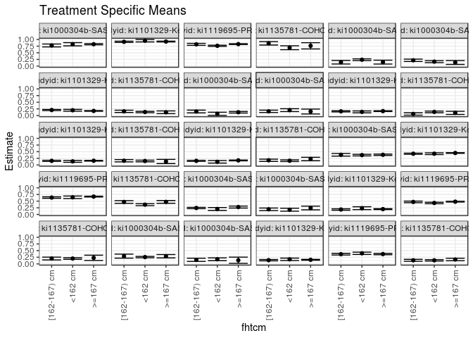

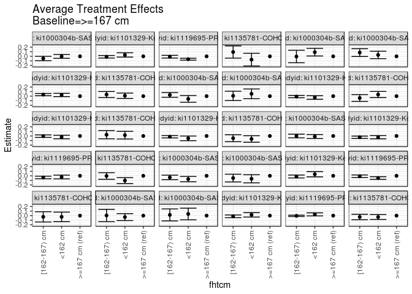

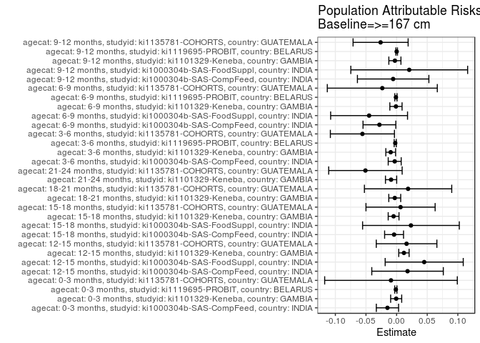

## Results Table

### Parameter: TSM

| agecat | studyid | country | intervention_level | baseline_level | estimate | ci_lower | ci_upper |
| --- | --- | --- | --- | --- | --- | --- | --- |
| 0-3 months | ki1000304b-SAS-CompFeed | INDIA | >=167 cm | NA | 0.8221166 | 0.7988335 | 0.8453996 |
| 0-3 months | ki1000304b-SAS-CompFeed | INDIA | <162 cm | NA | 0.8206412 | 0.7597955 | 0.8814870 |
| 0-3 months | ki1000304b-SAS-CompFeed | INDIA | [162-167) cm | NA | 0.7745989 | 0.7203581 | 0.8288396 |
| 0-3 months | ki1101329-Keneba | GAMBIA | >=167 cm | NA | 0.9218303 | 0.9064932 | 0.9371673 |
| 0-3 months | ki1101329-Keneba | GAMBIA | <162 cm | NA | 0.9523053 | 0.9078085 | 0.9968021 |
| 0-3 months | ki1101329-Keneba | GAMBIA | [162-167) cm | NA | 0.9118378 | 0.8884908 | 0.9351848 |
| 0-3 months | ki1119695-PROBIT | BELARUS | >=167 cm | NA | 0.8252297 | 0.8095615 | 0.8408978 |
| 0-3 months | ki1119695-PROBIT | BELARUS | <162 cm | NA | 0.7622877 | 0.7398977 | 0.7846776 |
| 0-3 months | ki1119695-PROBIT | BELARUS | [162-167) cm | NA | 0.8170110 | 0.7798261 | 0.8541959 |
| 0-3 months | ki1135781-COHORTS | GUATEMALA | >=167 cm | NA | 0.7616245 | 0.6442668 | 0.8789822 |
| 0-3 months | ki1135781-COHORTS | GUATEMALA | <162 cm | NA | 0.6891013 | 0.6154640 | 0.7627387 |
| 0-3 months | ki1135781-COHORTS | GUATEMALA | [162-167) cm | NA | 0.8556983 | 0.7914416 | 0.9199549 |
| 3-6 months | ki1000304b-SAS-CompFeed | INDIA | >=167 cm | NA | 0.3832837 | 0.3562243 | 0.4103431 |
| 3-6 months | ki1000304b-SAS-CompFeed | INDIA | <162 cm | NA | 0.3716833 | 0.3408697 | 0.4024968 |
| 3-6 months | ki1000304b-SAS-CompFeed | INDIA | [162-167) cm | NA | 0.3827366 | 0.3334464 | 0.4320269 |
| 3-6 months | ki1101329-Keneba | GAMBIA | >=167 cm | NA | 0.4510309 | 0.4377209 | 0.4643409 |
| 3-6 months | ki1101329-Keneba | GAMBIA | <162 cm | NA | 0.4240612 | 0.3911826 | 0.4569399 |
| 3-6 months | ki1101329-Keneba | GAMBIA | [162-167) cm | NA | 0.4235976 | 0.4024279 | 0.4447673 |
| 3-6 months | ki1119695-PROBIT | BELARUS | >=167 cm | NA | 0.6707673 | 0.6554204 | 0.6861142 |
| 3-6 months | ki1119695-PROBIT | BELARUS | <162 cm | NA | 0.6449419 | 0.5970670 | 0.6928168 |
| 3-6 months | ki1119695-PROBIT | BELARUS | [162-167) cm | NA | 0.6349226 | 0.6066112 | 0.6632340 |
| 3-6 months | ki1135781-COHORTS | GUATEMALA | >=167 cm | NA | 0.4720617 | 0.4201028 | 0.5240207 |
| 3-6 months | ki1135781-COHORTS | GUATEMALA | <162 cm | NA | 0.3678730 | 0.3291153 | 0.4066306 |
| 3-6 months | ki1135781-COHORTS | GUATEMALA | [162-167) cm | NA | 0.4688748 | 0.4187420 | 0.5190076 |
| 6-9 months | ki1000304b-SAS-CompFeed | INDIA | >=167 cm | NA | 0.2773582 | 0.2395889 | 0.3151275 |
| 6-9 months | ki1000304b-SAS-CompFeed | INDIA | <162 cm | NA | 0.2059215 | 0.1517621 | 0.2600809 |
| 6-9 months | ki1000304b-SAS-CompFeed | INDIA | [162-167) cm | NA | 0.2420191 | 0.2166376 | 0.2674005 |
| 6-9 months | ki1000304b-SAS-FoodSuppl | INDIA | >=167 cm | NA | 0.2426962 | 0.1728130 | 0.3125793 |
| 6-9 months | ki1000304b-SAS-FoodSuppl | INDIA | <162 cm | NA | 0.1780284 | 0.1224967 | 0.2335601 |
| 6-9 months | ki1000304b-SAS-FoodSuppl | INDIA | [162-167) cm | NA | 0.1932408 | 0.1457603 | 0.2407213 |

[output cut: 60 more lines]

### Parameter: E(Y)

| agecat | studyid | country | intervention_level | baseline_level | estimate | ci_lower | ci_upper |
| --- | --- | --- | --- | --- | --- | --- | --- |
| 0-3 months | ki1000304b-SAS-CompFeed | INDIA | NA | NA | 0.8071786 | 0.7733424 | 0.8410149 |
| 0-3 months | ki1101329-Keneba | GAMBIA | NA | NA | 0.9211456 | 0.9088113 | 0.9334799 |
| 0-3 months | ki1119695-PROBIT | BELARUS | NA | NA | 0.8239823 | 0.8076461 | 0.8403185 |
| 0-3 months | ki1135781-COHORTS | GUATEMALA | NA | NA | 0.7524624 | 0.7028441 | 0.8020806 |
| 3-6 months | ki1000304b-SAS-CompFeed | INDIA | NA | NA | 0.3801877 | 0.3590679 | 0.4013076 |
| 3-6 months | ki1101329-Keneba | GAMBIA | NA | NA | 0.4414007 | 0.4306421 | 0.4521592 |
| 3-6 months | ki1119695-PROBIT | BELARUS | NA | NA | 0.6685496 | 0.6529825 | 0.6841168 |
| 3-6 months | ki1135781-COHORTS | GUATEMALA | NA | NA | 0.4162288 | 0.3874235 | 0.4450342 |
| 6-9 months | ki1000304b-SAS-CompFeed | INDIA | NA | NA | 0.2492984 | 0.2183092 | 0.2802876 |
| 6-9 months | ki1000304b-SAS-FoodSuppl | INDIA | NA | NA | 0.1977764 | 0.1651439 | 0.2304089 |
| 6-9 months | ki1101329-Keneba | GAMBIA | NA | NA | 0.1996667 | 0.1855792 | 0.2137542 |
| 6-9 months | ki1119695-PROBIT | BELARUS | NA | NA | 0.4783706 | 0.4634008 | 0.4933404 |
| 6-9 months | ki1135781-COHORTS | GUATEMALA | NA | NA | 0.2045409 | 0.1778851 | 0.2311966 |
| 9-12 months | ki1000304b-SAS-CompFeed | INDIA | NA | NA | 0.2818834 | 0.2662532 | 0.2975135 |
| 9-12 months | ki1000304b-SAS-FoodSuppl | INDIA | NA | NA | 0.1575080 | 0.1170763 | 0.1979397 |
| 9-12 months | ki1101329-Keneba | GAMBIA | NA | NA | 0.1517153 | 0.1384995 | 0.1649312 |
| 9-12 months | ki1119695-PROBIT | BELARUS | NA | NA | 0.3701228 | 0.3438261 | 0.3964196 |
| 9-12 months | ki1135781-COHORTS | GUATEMALA | NA | NA | 0.1388128 | 0.1185925 | 0.1590330 |
| 12-15 months | ki1000304b-SAS-CompFeed | INDIA | NA | NA | 0.1663852 | 0.1509217 | 0.1818488 |
| 12-15 months | ki1000304b-SAS-FoodSuppl | INDIA | NA | NA | 0.1804270 | 0.1523220 | 0.2085320 |
| 12-15 months | ki1101329-Keneba | GAMBIA | NA | NA | 0.1849266 | 0.1739388 | 0.1959143 |
| 12-15 months | ki1135781-COHORTS | GUATEMALA | NA | NA | 0.1389485 | 0.1174123 | 0.1604847 |
| 15-18 months | ki1000304b-SAS-CompFeed | INDIA | NA | NA | 0.1200575 | 0.1025929 | 0.1375222 |
| 15-18 months | ki1000304b-SAS-FoodSuppl | INDIA | NA | NA | 0.1747121 | 0.1409944 | 0.2084298 |
| 15-18 months | ki1101329-Keneba | GAMBIA | NA | NA | 0.1612322 | 0.1498772 | 0.1725872 |
| 15-18 months | ki1135781-COHORTS | GUATEMALA | NA | NA | 0.1069536 | 0.0823544 | 0.1315529 |
| 18-21 months | ki1101329-Keneba | GAMBIA | NA | NA | 0.1562372 | 0.1442891 | 0.1681853 |
| 18-21 months | ki1135781-COHORTS | GUATEMALA | NA | NA | 0.1508100 | 0.1263907 | 0.1752293 |
| 21-24 months | ki1101329-Keneba | GAMBIA | NA | NA | 0.1630013 | 0.1513318 | 0.1746708 |
| 21-24 months | ki1135781-COHORTS | GUATEMALA | NA | NA | 0.1742456 | 0.1505926 | 0.1978987 |

### Parameter: ATE

| agecat | studyid | country | intervention_level | baseline_level | estimate | ci_lower | ci_upper |
| --- | --- | --- | --- | --- | --- | --- | --- |
| 0-3 months | ki1000304b-SAS-CompFeed | INDIA | >=167 cm | >=167 cm | 0.0000000 | 0.0000000 | 0.0000000 |
| 0-3 months | ki1000304b-SAS-CompFeed | INDIA | <162 cm | >=167 cm | -0.0014753 | -0.0435968 | 0.0406461 |
| 0-3 months | ki1000304b-SAS-CompFeed | INDIA | [162-167) cm | >=167 cm | -0.0475177 | -0.0959926 | 0.0009572 |
| 0-3 months | ki1101329-Keneba | GAMBIA | >=167 cm | >=167 cm | 0.0000000 | 0.0000000 | 0.0000000 |
| 0-3 months | ki1101329-Keneba | GAMBIA | <162 cm | >=167 cm | 0.0304750 | -0.0165908 | 0.0775408 |
| 0-3 months | ki1101329-Keneba | GAMBIA | [162-167) cm | >=167 cm | -0.0099925 | -0.0379264 | 0.0179415 |
| 0-3 months | ki1119695-PROBIT | BELARUS | >=167 cm | >=167 cm | 0.0000000 | 0.0000000 | 0.0000000 |
| 0-3 months | ki1119695-PROBIT | BELARUS | <162 cm | >=167 cm | -0.0629420 | -0.0831825 | -0.0427014 |
| 0-3 months | ki1119695-PROBIT | BELARUS | [162-167) cm | >=167 cm | -0.0082186 | -0.0379629 | 0.0215256 |
| 0-3 months | ki1135781-COHORTS | GUATEMALA | >=167 cm | >=167 cm | 0.0000000 | 0.0000000 | 0.0000000 |
| 0-3 months | ki1135781-COHORTS | GUATEMALA | <162 cm | >=167 cm | -0.0725232 | -0.2110702 | 0.0660239 |
| 0-3 months | ki1135781-COHORTS | GUATEMALA | [162-167) cm | >=167 cm | 0.0940737 | -0.0397237 | 0.2278712 |
| 3-6 months | ki1000304b-SAS-CompFeed | INDIA | >=167 cm | >=167 cm | 0.0000000 | 0.0000000 | 0.0000000 |
| 3-6 months | ki1000304b-SAS-CompFeed | INDIA | <162 cm | >=167 cm | -0.0116004 | -0.0553725 | 0.0321716 |
| 3-6 months | ki1000304b-SAS-CompFeed | INDIA | [162-167) cm | >=167 cm | -0.0005471 | -0.0404739 | 0.0393797 |
| 3-6 months | ki1101329-Keneba | GAMBIA | >=167 cm | >=167 cm | 0.0000000 | 0.0000000 | 0.0000000 |
| 3-6 months | ki1101329-Keneba | GAMBIA | <162 cm | >=167 cm | -0.0269697 | -0.0624403 | 0.0085009 |
| 3-6 months | ki1101329-Keneba | GAMBIA | [162-167) cm | >=167 cm | -0.0274333 | -0.0524395 | -0.0024271 |
| 3-6 months | ki1119695-PROBIT | BELARUS | >=167 cm | >=167 cm | 0.0000000 | 0.0000000 | 0.0000000 |
| 3-6 months | ki1119695-PROBIT | BELARUS | <162 cm | >=167 cm | -0.0258253 | -0.0669269 | 0.0152762 |
| 3-6 months | ki1119695-PROBIT | BELARUS | [162-167) cm | >=167 cm | -0.0358447 | -0.0639485 | -0.0077408 |
| 3-6 months | ki1135781-COHORTS | GUATEMALA | >=167 cm | >=167 cm | 0.0000000 | 0.0000000 | 0.0000000 |
| 3-6 months | ki1135781-COHORTS | GUATEMALA | <162 cm | >=167 cm | -0.1041888 | -0.1690107 | -0.0393668 |
| 3-6 months | ki1135781-COHORTS | GUATEMALA | [162-167) cm | >=167 cm | -0.0031869 | -0.0753882 | 0.0690144 |
| 6-9 months | ki1000304b-SAS-CompFeed | INDIA | >=167 cm | >=167 cm | 0.0000000 | 0.0000000 | 0.0000000 |
| 6-9 months | ki1000304b-SAS-CompFeed | INDIA | <162 cm | >=167 cm | -0.0714367 | -0.1296056 | -0.0132678 |
| 6-9 months | ki1000304b-SAS-CompFeed | INDIA | [162-167) cm | >=167 cm | -0.0353391 | -0.0849318 | 0.0142536 |
| 6-9 months | ki1000304b-SAS-FoodSuppl | INDIA | >=167 cm | >=167 cm | 0.0000000 | 0.0000000 | 0.0000000 |
| 6-9 months | ki1000304b-SAS-FoodSuppl | INDIA | <162 cm | >=167 cm | -0.0646678 | -0.1539282 | 0.0245927 |
| 6-9 months | ki1000304b-SAS-FoodSuppl | INDIA | [162-167) cm | >=167 cm | -0.0494554 | -0.1339424 | 0.0350316 |

[output cut: 60 more lines]

### Parameter: PAR

| agecat | studyid | country | intervention_level | baseline_level | estimate | ci_lower | ci_upper |
| --- | --- | --- | --- | --- | --- | --- | --- |
| 0-3 months | ki1000304b-SAS-CompFeed | INDIA | >=167 cm | NA | -0.0149379 | -0.0331161 | 0.0032402 |
| 0-3 months | ki1101329-Keneba | GAMBIA | >=167 cm | NA | -0.0006846 | -0.0097084 | 0.0083391 |
| 0-3 months | ki1119695-PROBIT | BELARUS | >=167 cm | NA | -0.0012474 | -0.0030305 | 0.0005358 |
| 0-3 months | ki1135781-COHORTS | GUATEMALA | >=167 cm | NA | -0.0091621 | -0.1174550 | 0.0991307 |
| 3-6 months | ki1000304b-SAS-CompFeed | INDIA | >=167 cm | NA | -0.0030960 | -0.0136872 | 0.0074952 |
| 3-6 months | ki1101329-Keneba | GAMBIA | >=167 cm | NA | -0.0096302 | -0.0175927 | -0.0016677 |
| 3-6 months | ki1119695-PROBIT | BELARUS | >=167 cm | NA | -0.0022176 | -0.0039363 | -0.0004989 |
| 3-6 months | ki1135781-COHORTS | GUATEMALA | >=167 cm | NA | -0.0558329 | -0.1081605 | -0.0035053 |
| 6-9 months | ki1000304b-SAS-CompFeed | INDIA | >=167 cm | NA | -0.0280598 | -0.0548271 | -0.0012926 |
| 6-9 months | ki1000304b-SAS-FoodSuppl | INDIA | >=167 cm | NA | -0.0449198 | -0.1077016 | 0.0178620 |
| 6-9 months | ki1101329-Keneba | GAMBIA | >=167 cm | NA | -0.0010516 | -0.0110292 | 0.0089259 |
| 6-9 months | ki1119695-PROBIT | BELARUS | >=167 cm | NA | -0.0011123 | -0.0029351 | 0.0007105 |
| 6-9 months | ki1135781-COHORTS | GUATEMALA | >=167 cm | NA | -0.0233583 | -0.1131790 | 0.0664624 |
| 9-12 months | ki1000304b-SAS-CompFeed | INDIA | >=167 cm | NA | -0.0056353 | -0.0639706 | 0.0527001 |
| 9-12 months | ki1000304b-SAS-FoodSuppl | INDIA | >=167 cm | NA | 0.0206151 | -0.0747689 | 0.1159992 |
| 9-12 months | ki1101329-Keneba | GAMBIA | >=167 cm | NA | -0.0027795 | -0.0126629 | 0.0071038 |
| 9-12 months | ki1119695-PROBIT | BELARUS | >=167 cm | NA | 0.0001139 | -0.0011911 | 0.0014189 |
| 9-12 months | ki1135781-COHORTS | GUATEMALA | >=167 cm | NA | -0.0261154 | -0.0710698 | 0.0188389 |
| 12-15 months | ki1000304b-SAS-CompFeed | INDIA | >=167 cm | NA | 0.0178823 | -0.0405185 | 0.0762831 |
| 12-15 months | ki1000304b-SAS-FoodSuppl | INDIA | >=167 cm | NA | 0.0450908 | -0.0186514 | 0.1088330 |
| 12-15 months | ki1101329-Keneba | GAMBIA | >=167 cm | NA | 0.0119654 | 0.0034926 | 0.0204382 |
| 12-15 months | ki1135781-COHORTS | GUATEMALA | >=167 cm | NA | 0.0162748 | -0.0332170 | 0.0657667 |
| 15-18 months | ki1000304b-SAS-CompFeed | INDIA | >=167 cm | NA | -0.0041254 | -0.0195712 | 0.0113204 |
| 15-18 months | ki1000304b-SAS-FoodSuppl | INDIA | >=167 cm | NA | 0.0234388 | -0.0555280 | 0.1024056 |
| 15-18 months | ki1101329-Keneba | GAMBIA | >=167 cm | NA | -0.0049062 | -0.0137111 | 0.0038987 |
| 15-18 months | ki1135781-COHORTS | GUATEMALA | >=167 cm | NA | 0.0064719 | -0.0499944 | 0.0629382 |
| 18-21 months | ki1101329-Keneba | GAMBIA | >=167 cm | NA | -0.0030194 | -0.0127462 | 0.0067075 |
| 18-21 months | ki1135781-COHORTS | GUATEMALA | >=167 cm | NA | 0.0187397 | -0.0525614 | 0.0900408 |
| 21-24 months | ki1101329-Keneba | GAMBIA | >=167 cm | NA | -0.0090198 | -0.0181935 | 0.0001539 |
| 21-24 months | ki1135781-COHORTS | GUATEMALA | >=167 cm | NA | -0.0509169 | -0.1109123 | 0.0090784 |